# Base Setup

```python
import pandas as pd
import numpy as np
from matplotlib import pyplot as plt
import seaborn as sns

pd.options.mode.chained_assignment = None
```

```python
df = pd.read_csv('./casestudy.csv')
df = df.dropna()
df.head()
```

|  | Unnamed: 0 | customer_email | net_revenue | year |
| --- | --- | --- | --- | --- |
| 0 | 0 | nhknapwsbx@gmail.com | 249.92 | 2015 |
| 1 | 1 | joiuzbvcpn@gmail.com | 87.61 | 2015 |
| 2 | 2 | ukkjctepxt@gmail.com | 168.38 | 2015 |
| 3 | 3 | gykatilzrt@gmail.com | 62.40 | 2015 |
| 4 | 4 | mmsgsrtxah@gmail.com | 43.08 | 2015 |

# Information Extraction

• Total revenue for the current year

```python
year_wise_total_revenue = df.groupby('year')['net_revenue'].sum()
print(year_wise_total_revenue)
```

```
year
2015    29036749.19
2016    25730943.59
2017    31417495.03
Name: net_revenue, dtype: float64
```

• New Customer Revenue e.g. new customers not present in previous year only

```python
year_2015_data = df.query('year == 2015')
year_2016_data = df.query('year == 2016')
year_2017_data = df.query('year == 2017')

new_customer_2015 = year_2015_data
new_customer_2016 = year_2016_data[~year_2016_data.customer_email.isin(
    year_2015_data.customer_email)]
new_customer_2017 = year_2017_data[~year_2017_data.customer_email.isin(
    year_2016_data.customer_email)]

print(new_customer_2015.net_revenue.sum())
print(new_customer_2016.net_revenue.sum())
print(new_customer_2017.net_revenue.sum())
```

```
29036749.189999994
18245491.01
28776235.039999995
```

• Existing Customer Growth. To calculate this, use the Revenue of existing customers for current year –(minus) Revenue of existing customers from the previous year

```python
customer_growth_2015 = 0
customer_growth_2016 = year_2016_data.net_revenue.sum() - \
    year_2015_data.net_revenue.sum()
customer_growth_2017 = year_2017_data.net_revenue.sum() - \
    year_2016_data.net_revenue.sum()
print(customer_growth_2015)
print(customer_growth_2016)
print(customer_growth_2017)
```

```
0
-3305805.599999994
5686551.440000016
```

• Revenue lost from attrition

```python
lost_customer_2015 = 0
lost_customer_2016 = year_2015_data[~year_2015_data.customer_email.isin(
    year_2016_data.customer_email)]
lost_customer_2017 = year_2016_data[~year_2016_data.customer_email.isin(
    year_2017_data.customer_email)]

print(lost_customer_2015)
print(lost_customer_2016.net_revenue.sum())
print(lost_customer_2017.net_revenue.sum())
```

```
0
21571632.070000004
23110294.939999998
```

• Existing Customer Revenue Current Year • Existing Customer Revenue Prior Year

```python
revenue_2015 = year_2015_data.net_revenue.sum()
revenue_2016 = year_2016_data.net_revenue.sum()
revenue_2017 = year_2017_data.net_revenue.sum()

print(revenue_2015)
print(revenue_2016)
print(revenue_2017)
```

```
29036749.189999994
25730943.59
31417495.030000016
```

• Total Customers Current Year • Total Customers Previous Year

```python
customers_2015 = len(year_2015_data.customer_email.unique())
customers_2016 = len(year_2016_data.customer_email.unique())
customers_2017 = len(year_2017_data.customer_email.unique())

print(customers_2015)
print(customers_2016)
print(customers_2017)
```

```
231294
204646
249987
```

• New Customers

```python
print(new_customer_2015.customer_email.unique())
print(new_customer_2016.customer_email.unique())
print(new_customer_2017.customer_email.unique())
```

```
[' nhknapwsbx@gmail.com' 'joiuzbvcpn@gmail.com' 'ukkjctepxt@gmail.com' ...
 ' vanasezjpw@gmail.com' 'dnpremlztb@gmail.com' 'qsgswrpycl@gmail.com']
[' mwrossuukz@gmail.com' 'gkwsoupawk@gmail.com' 'vlyigtgfzs@gmail.com' ...
 ' rdotspqdxi@gmail.com' 'fkweqlmmjw@gmail.com' 'pidugzoeej@gmail.com']
['mwrossuukz@gmail.com' 'qvjfterwnk@gmail.com ' ' vlyigtgfzs@gmail.com'
 ... 'appaplmgko@gmail.com' 'wvkpmwsgck@gmail.com' ' aregboumbw@gmail.com']
```

• Lost Customers

```python
print(lost_customer_2015)
print(lost_customer_2016.customer_email.unique())
print(lost_customer_2017.customer_email.unique())
```

```
0
[' nhknapwsbx@gmail.com' 'joiuzbvcpn@gmail.com' 'ukkjctepxt@gmail.com' ...
 ' vanasezjpw@gmail.com' 'dnpremlztb@gmail.com' 'qsgswrpycl@gmail.com']
[' mwrossuukz@gmail.com' 'gkwsoupawk@gmail.com' 'vlyigtgfzs@gmail.com' ...
 ' rdotspqdxi@gmail.com' 'pidugzoeej@gmail.com' ' kxqglfdktu@gmail.com']
```

# Insight Visualization

#### Top 50 Existing Customers Purchase Trend

This chart shows how the top 50 customers who generated revenue for all the three years and their expense per year trend. (Customer Purchase Pattern).

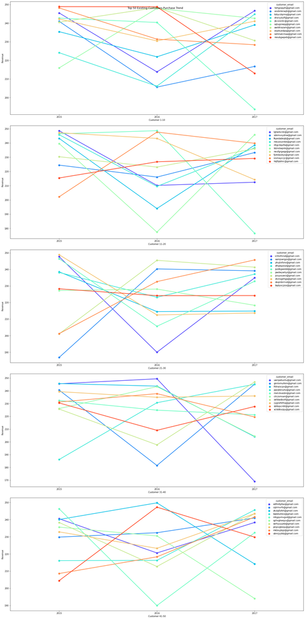

```python
year_2015_data = df.query('year == 2015')
year_2016_data = df.query('year == 2016')
year_2017_data = df.query('year == 2017')

customers_2015 = year_2015_data
existing_customer_2016 = year_2016_data[year_2016_data.customer_email.isin(
    year_2015_data.customer_email.unique())]
existing_customer_2017 = year_2017_data[year_2017_data.customer_email.isin(
    year_2016_data.customer_email.unique())]
all_time_existing_customer_data = df[df.customer_email.isin(
    existing_customer_2017.customer_email.unique())]

top_50_revenue_generating_all_time_existing_customers = all_time_existing_customer_data.groupby(
    ['customer_email'])['net_revenue'].sum().reset_index(name='net_revenue').nlargest(50, columns=['net_revenue'])

top_50_all_time_existing_customer_data = pd.DataFrame(all_time_existing_customer_data[all_time_existing_customer_data.customer_email.isin(
    top_50_revenue_generating_all_time_existing_customers.customer_email)])


fig, axes = plt.subplots(5, 1, figsize=(20, 40))
plt.tight_layout(pad=3)
fig.suptitle('Top 50 Existing Customers Purchase Trend')

data = top_50_all_time_existing_customer_data[top_50_all_time_existing_customer_data.customer_email.isin(
    top_50_all_time_existing_customer_data.customer_email.unique()[0:10])]
sns.pointplot(ax=axes[0], hue='customer_email',
              y='net_revenue', data=data, palette='rainbow', x='year')
axes[0].set_xlabel('Customer 1-10')
axes[0].set_ylabel('Revenue')

data = top_50_all_time_existing_customer_data[top_50_all_time_existing_customer_data.customer_email.isin(
    top_50_all_time_existing_customer_data.customer_email.unique()[10:20])]
sns.pointplot(ax=axes[1], hue='customer_email',
              y='net_revenue', data=data, palette='rainbow', x='year')
axes[1].set_xlabel('Customer 11-20')
axes[1].set_ylabel('Revenue')

data = top_50_all_time_existing_customer_data[top_50_all_time_existing_customer_data.customer_email.isin(
    top_50_all_time_existing_customer_data.customer_email.unique()[20:30])]
sns.pointplot(ax=axes[2], hue='customer_email',
              y='net_revenue', data=data, palette='rainbow', x='year')
axes[2].set_xlabel('Customer 21-30')
axes[2].set_ylabel('Revenue')

data = top_50_all_time_existing_customer_data[top_50_all_time_existing_customer_data.customer_email.isin(
    top_50_all_time_existing_customer_data.customer_email.unique()[30:40])]
sns.pointplot(ax=axes[3], hue='customer_email',
              y='net_revenue', data=data, palette='rainbow', x='year')
axes[3].set_xlabel('Customer 31-40')
axes[3].set_ylabel('Revenue')

data = top_50_all_time_existing_customer_data[top_50_all_time_existing_customer_data.customer_email.isin(
    top_50_all_time_existing_customer_data.customer_email.unique()[40:50])]
sns.pointplot(ax=axes[4], hue='customer_email',
              y='net_revenue', data=data, palette='rainbow', x='year')
axes[4].set_xlabel('Customer 41-50')
axes[4].set_ylabel('Revenue')
```

#### Existing vs New Customers Revenue Analysis

Revenue Generation Analysis over existing customers versus new customers every year.

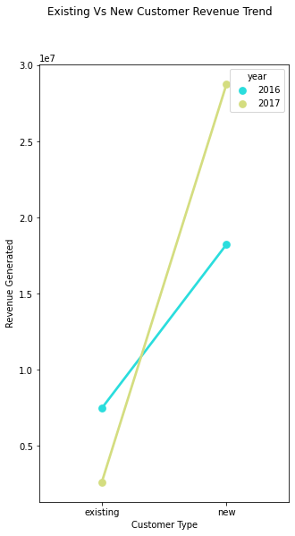

```python
year_2015_data = df.query('year == 2015')
year_2016_data = df.query('year == 2016')
year_2017_data = df.query('year == 2017')

new_customer_2016 = year_2016_data[~year_2016_data.customer_email.isin(
    year_2015_data.customer_email)]
new_customer_2016.insert(1, 'type', 'new')
existing_customer_2016 = year_2016_data[year_2016_data.customer_email.isin(
    year_2015_data.customer_email.unique())]
existing_customer_2016.insert(1, 'type', 'existing')

new_customer_2017 = year_2017_data[~year_2017_data.customer_email.isin(
    year_2016_data.customer_email)]
new_customer_2017.insert(1, 'type', 'new')
existing_customer_2017 = year_2017_data[year_2017_data.customer_email.isin(
    year_2016_data.customer_email.unique())]
existing_customer_2017.insert(1, 'type', 'existing')

data_2016 = pd.concat(
    [new_customer_2016, existing_customer_2016], ignore_index=True)
data_2017 = pd.concat(
    [new_customer_2017, existing_customer_2017], ignore_index=True)

data = pd.concat([data_2016, data_2017], ignore_index=True)

data = data.groupby(['year', 'type'])[
    'net_revenue'].sum().reset_index(name='net_revenue')


plt.figure(figsize=(5, 9))
plt.tight_layout(pad=3)
plt.suptitle('Existing Vs New Customer Revenue Trend')
sns.pointplot(hue='year',y='net_revenue',data=data, palette='rainbow', x='type')
plt.xlabel('Customer Type')
plt.ylabel('Revenue Generated')
```

#### Top 50 Customers Who left in 2017 and degraded between year 2015-16

This chart shows how customers who degraded on purchase in between 2016 and 2015 and completely stopped in the year 2017.\ (helps us ask for feedback from the customers or possible problems they may have faced)

```
[Text(0, 0, '2015'), Text(1, 0, '2016'), Text(2, 0, '2017'), Text(3, 0, '')]
```

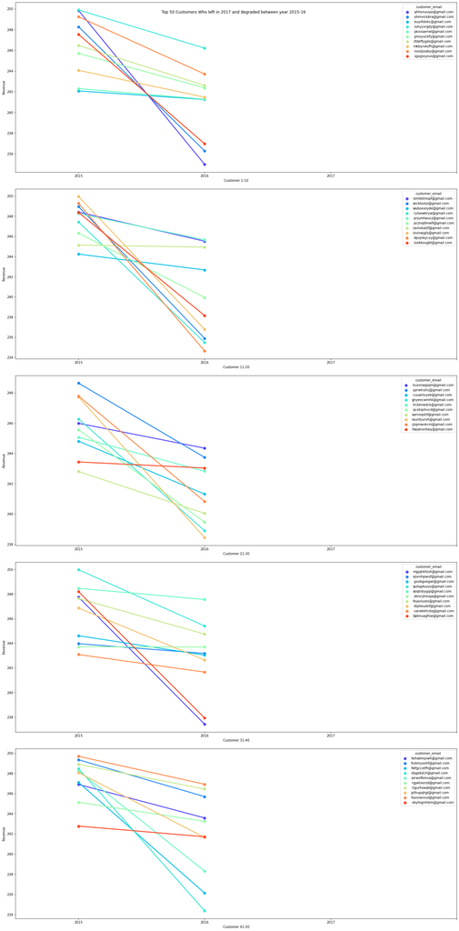

```python
year_2015_data = df.query('year == 2015')
year_2016_data = df.query('year == 2016')
year_2017_data = df.query('year == 2017')

customers_2015 = year_2015_data
existing_customer_2016 = year_2016_data[year_2016_data.customer_email.isin(
    year_2015_data.customer_email.unique())]
customers_left_2017 = existing_customer_2016[~existing_customer_2016.customer_email.isin(
    year_2017_data.customer_email.unique())]


data = df[df.customer_email.isin(
    customers_left_2017.customer_email.unique())]

data_2015 = data.query('year == 2015')
data_2015.rename(columns={'net_revenue': 'net_revenue_2015'}, inplace=True)

data_2016 = data.query('year == 2016')
data_2016.rename(columns={'net_revenue': 'net_revenue_2016'}, inplace=True)


data_merged = pd.merge(data_2015, data_2016, how="left", on=["customer_email"])
degrading_customers = data_merged[data_merged.net_revenue_2015 >
                                  data_merged.net_revenue_2016]

data = df[df.customer_email.isin(
    degrading_customers.customer_email.unique())]

top_50_revenue_generating_among_degrading_customers = data[data.customer_email.isin(data.groupby(
    ['customer_email'])['net_revenue'].sum().reset_index(name='net_revenue').nlargest(50, columns=['net_revenue']).customer_email.unique())]


fig, axes = plt.subplots(5, 1, figsize=(20, 40))
plt.tight_layout(pad=3)
fig.suptitle('Top 50 Customers Who left in 2017 and degraded between year 2015-16')

data = top_50_revenue_generating_among_degrading_customers[top_50_revenue_generating_among_degrading_customers.customer_email.isin(
    top_50_revenue_generating_among_degrading_customers.customer_email.unique()[0:10])]
g = sns.pointplot(ax=axes[0], hue='customer_email',
                  y='net_revenue', data=data, palette='rainbow', x='year', xlim=(2015, 2017))
axes[0].set_xlabel('Customer 1-10')
axes[0].set_ylabel('Revenue')
g.set_xticks(range(3+1))
g.set_xticklabels(['2015', '2016', '2017', ''])

data = top_50_revenue_generating_among_degrading_customers[top_50_revenue_generating_among_degrading_customers.customer_email.isin(
    top_50_revenue_generating_among_degrading_customers.customer_email.unique()[10:20])]
g = sns.pointplot(ax=axes[1], hue='customer_email',
                  y='net_revenue', data=data, palette='rainbow', x='year')
axes[1].set_xlabel('Customer 11-20')
axes[1].set_ylabel('Revenue')
g.set_xticks(range(3+1))
g.set_xticklabels(['2015', '2016', '2017', ''])

data = top_50_revenue_generating_among_degrading_customers[top_50_revenue_generating_among_degrading_customers.customer_email.isin(
    top_50_revenue_generating_among_degrading_customers.customer_email.unique()[20:30])]
g = sns.pointplot(ax=axes[2], hue='customer_email',
                  y='net_revenue', data=data, palette='rainbow', x='year')
axes[2].set_xlabel('Customer 21-30')
axes[2].set_ylabel('Revenue')
g.set_xticks(range(3+1))
g.set_xticklabels(['2015', '2016', '2017', ''])

data = top_50_revenue_generating_among_degrading_customers[top_50_revenue_generating_among_degrading_customers.customer_email.isin(
    top_50_revenue_generating_among_degrading_customers.customer_email.unique()[30:40])]
g = sns.pointplot(ax=axes[3], hue='customer_email',
                  y='net_revenue', data=data, palette='rainbow', x='year')
axes[3].set_xlabel('Customer 31-40')
axes[3].set_ylabel('Revenue')
g.set_xticks(range(3+1))
g.set_xticklabels(['2015', '2016', '2017', ''])

data = top_50_revenue_generating_among_degrading_customers[top_50_revenue_generating_among_degrading_customers.customer_email.isin(
    top_50_revenue_generating_among_degrading_customers.customer_email.unique()[40:50])]
g = sns.pointplot(ax=axes[4], hue='customer_email',
                  y='net_revenue', data=data, palette='rainbow', x='year')
axes[4].set_xlabel('Customer 41-50')
axes[4].set_ylabel('Revenue')
g.set_xticks(range(3+1))
g.set_xticklabels(['2015', '2016', '2017', ''])
```